# R Training

Taylor G. White

February 13, 2019

# 1 Introduction

This is an intermediate level introduction to R, aimed at business analysts. It assumes you understand the basic syntax of the language, including how to create objects and run functions.

[DataCamp](https://campus.datacamp.com/courses/free-introduction-to-r/) has an interactive tutorial that will provide a good base to provide the necessary skills to make the most out of this tutorial.

This introduction will follow a realistic analysis of retail data that is provided freely on the internet. I wrote this document using something called [R Markdown](https://rmarkdown.rstudio.com/), which is a way to combine text and R code to generate dynamic reports in various formats.

## 1.1 Installing R

DataCamp does not go into details on how to actually get R and RStudio up and running. Follow this [guide](https://www.ics.uci.edu/~sternh/courses/210/InstallingRandRStudio.pdf) to get moving.

# 2 Load (and install) libraries for use

```r
# tidyverse contains a host of helpful packages that make data analysis in R a joy
# install.packages() will download a package (and its dependencies)
# install.packages('tidyverse')

# use the library() function to make that code available in your session
library(tidyverse)
```

# 3 Import and combine data

This directory contains a folder with several files that will be used in the initial analysis.

```r
# list.files() will get the list of files in the current working directory
list.files()
```

```
## [1] "R_Training.html"
## [2] "R_Training.rmd"
## [3] "R_Training_files"
## [4] "walmart-recruiting-store-sales-forecasting"
```

```r
# get the files in a specific folder:
list.files('walmart-recruiting-store-sales-forecasting/')
```

```
## [1] "features.csv"         "sampleSubmission.csv" "stores.csv"
## [4] "test.csv"             "train.csv"
```

```r
# get files with names matching a specific pattern (like csv for example) in the current directory or any subdirectory
list.files(pattern = 'csv', recursive = T)
```

```
## [1] "walmart-recruiting-store-sales-forecasting/features.csv"
## [2] "walmart-recruiting-store-sales-forecasting/sampleSubmission.csv"
## [3] "walmart-recruiting-store-sales-forecasting/stores.csv"
## [4] "walmart-recruiting-store-sales-forecasting/test.csv"
## [5] "walmart-recruiting-store-sales-forecasting/train.csv"
```

```r
stores_filename = list.files(pattern = 'stores', recursive = T) # note the recursive parameter is required, there is no stores data in the current directory

features_filename = list.files(pattern = 'features', recursive = T)

train_filename = list.files(pattern = 'train', recursive = T)

# warning -- make sure your pattern searches don't return multiple files if you intend to use filenames to read in later
```

Let’s import the stores.csv dataset. The first step is usually to open .csv files in excel or a similar program just to visually inspect the file for any irregularities (maybe there is information at the top of the file before the main data starts). This step can be done in R as well.

## 3.1 Import and inspect data

```r
# this will read the first ten lines of the stores file. The sep argument is the separator, or the character that splits individual data points. Since this is a .csv file, the actual separator is a comma (comma separated values), but I use a fake one (meaning the scan function will not split a value because the separator I chose isn't actually present) so you can see what the data looks like in the actual file.
scan(stores_filename, sep = '_', nlines = 10, what = 'character')
```

```
##  [1] "Store,Type,Size" "1,A,151315"      "2,A,202307"
##  [4] "3,B,37392"       "4,A,205863"      "5,B,34875"
##  [7] "6,A,202505"      "7,B,70713"       "8,A,155078"
## [10] "9,B,125833"
```

```r
# Since this looks like proper comma separated values, the data can be read in using a handy function from readr (loaded by tidyverse)
stores_data = read_csv(stores_filename)
# read_csv is similar to read.csv from base R, but it does some handy work to parse column formats (like dates)

# lets look at the top and bottom of the data
head(stores_data)
```

```
## # A tibble: 6 x 3
##   Store Type    Size
##   <int> <chr>  <int>
## 1     1 A     151315
## 2     2 A     202307
## 3     3 B      37392
## 4     4 A     205863
## 5     5 B      34875
## 6     6 A     202505
```

```r
tail(stores_data)
```

```
## # A tibble: 6 x 3
##   Store Type    Size
##   <int> <chr>  <int>
## 1    40 A     155083
## 2    41 A     196321
## 3    42 C      39690
## 4    43 C      41062
## 5    44 C      39910
## 6    45 B     118221
```

```r
# let's look at the column classes (data types)
sapply(stores_data, class) # this loops over every column and applies the class function
```

```
##       Store        Type        Size
##   "integer" "character"   "integer"
```

```r
### let's now read in the other two files
### By this point, I forgot what the variables were that I stored the other filenames in:
ls() # prints out the objects in memory
```

```
## [1] "features_filename" "stores_data"       "stores_filename"
## [4] "train_filename"
```

```r
# notice I use structured and descriptive names for the objects I create. This helps with readability and reduces errors.
features_data = read_csv(features_filename)
head(features_data)
```

```
## # A tibble: 6 x 12
##   Store Date       Temperature Fuel_Price MarkDown1 MarkDown2 MarkDown3
##   <int> <date>           <dbl>      <dbl>     <dbl>     <dbl>     <dbl>
## 1     1 2010-02-05        42.3       2.57        NA        NA        NA
## 2     1 2010-02-12        38.5       2.55        NA        NA        NA
## 3     1 2010-02-19        39.9       2.51        NA        NA        NA
## 4     1 2010-02-26        46.6       2.56        NA        NA        NA
## 5     1 2010-03-05        46.5       2.62        NA        NA        NA
## 6     1 2010-03-12        57.8       2.67        NA        NA        NA
## # ... with 5 more variables: MarkDown4 <dbl>, MarkDown5 <dbl>, CPI <dbl>,
## #   Unemployment <dbl>, IsHoliday <lgl>
```

```r
# R is very finicky about data types. This data.frame, features_data already has columns parsed into useful formats. Date has been parsed into "Date" class and predictors like Temperator and Fuel_Price have been parsed into numeric values. Commonly, prices might be saved as a character, e.g. "$10", in which case R would read that value as a character class vector. I'll say something later about gotchas like this.

sapply(features_data, class)
```

```
##        Store         Date  Temperature   Fuel_Price    MarkDown1
##    "integer"       "Date"    "numeric"    "numeric"    "numeric"
##    MarkDown2    MarkDown3    MarkDown4    MarkDown5          CPI
##    "numeric"    "numeric"    "numeric"    "numeric"    "numeric"
## Unemployment    IsHoliday
##    "numeric"    "logical"
```

```r
# View(features_data) this will open the dataset in RStudio's viewer pane

train_data = read_csv(train_filename)
head(train_data)
```

```
## # A tibble: 6 x 5
##   Store  Dept Date       Weekly_Sales IsHoliday
##   <int> <int> <date>            <dbl> <lgl>
## 1     1     1 2010-02-05       24924. FALSE
## 2     1     1 2010-02-12       46039. TRUE
## 3     1     1 2010-02-19       41596. FALSE
## 4     1     1 2010-02-26       19404. FALSE
## 5     1     1 2010-03-05       21828. FALSE
## 6     1     1 2010-03-12       21043. FALSE
```

By this point of the analysis, I have read in my main analytical files. `stores_data` has information about each store (albeit not much), `features_data` has weekly information about various predictors, from promotions, to economic predictors. `train_data` tells me which store/department combinations I should use to train for my models as well as their weekly sales. This is an important point – in the real world, we want to predict events that haven’t happened yet. In this case, we will have data that we have already fully observed. In order to replicate the fact that we won’t be able to see the future (or some subset of events), we hold back some data to “test” the quality of our predictions. Once we have tested many different models, we can use the best performing ones (or a combination of them) to predict the future.

This is a good time to think about the problem at hand – the goal is to predict weekly sales for stores/departments in the test dataset. Do we have all the data we need to make such predictions? Is there data elsewhere that can be used to shed light on this problem?

Further, do we really understand the data included here? Are gas prices reported nationally for a given week or are they particular to a given geography? Is unemployment reported nationally or regionally and at what frequency? What about the consumer price index (CPI)? This information can be obtained by visually inpecting individual data values, or by plotting data graphically. I prefer the latter approach.

## 3.2 Exploratory Data Analysis (EDA) with Graphs

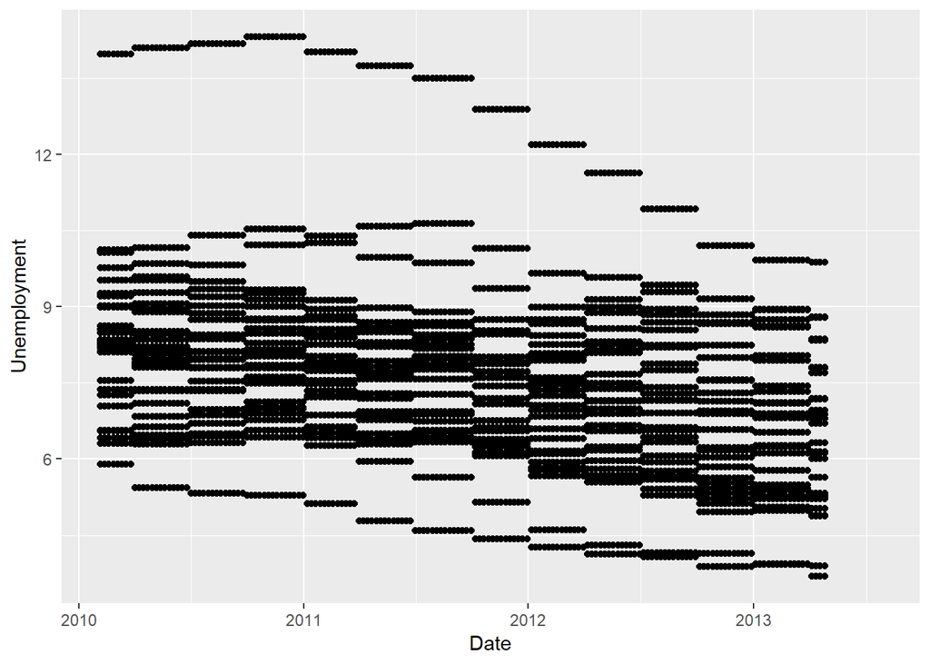

```r
# this step is unnecessary since ggplot2 is loaded by tidyverse, but this makes it clearer that I am using this graphics package
library(ggplot2)

# let's make a scatterplot of unemployment by week

# ggplot is the main command. The first argument is the data.frame that contains the data your are plotting.
# aes() stands for aesthetics, and it sets up the overall rules for the plot -- which values will be used for # which features.
# geom_point() plots points on the chart, one for every combination of Date,Unemployment on the xy axis.
ggplot(features_data, aes(Date, Unemployment)) +
  geom_point()
```

What about gas prices, consumer prices, and temperature? One way to investigate is to have individual `ggplot` commands like the one above for each of the variables I want to investigate. But what if you had to do that for many columns? Your code would become hard to read and error prone very quickly.

Another approach is to reformat this “wide” dataset into a long one, by pulling columns down and stacking the data for easy plotting.